# Supervised Learning - Foundations: ReCell

### Observations

- The top three device brands by average resale price are OnePlus, Apple, and Google.
- Looking at the boxplot, looks likes ZTE and Huawei has at least one (if not more) devices that go for 700+ Euro used.

```python
# new_price vs brand_name
# new_price average per brand_name
df1.groupby('brand_name')['new_price'].mean().sort_values(ascending = False)
```

```
brand_name
Apple         623.162564
OnePlus       558.230909
Google        474.716667
Oppo          341.912326
Huawei        329.984143
Vivo          320.268291
Samsung       296.458592
Sony          284.586744
Meizu         269.569194
Xiaomi        259.326364
Gionee        255.379286
Asus          254.049344
HTC           249.853818
LG            241.547264
Honor         236.857845
BlackBerry    234.774545
ZTE           216.908143
Motorola      208.023491
Coolpad       194.285455
Others        193.258008
Lenovo        192.096667
Realme        186.030488
Acer          172.867647
Panasonic     171.426596
Microsoft     166.366818
Nokia         146.256132
Alcatel       144.951240
XOLO          130.898571
Karbonn       109.371724
Micromax      108.686239
Lava          107.424722
Infinix       106.017000
Spice          98.000000
Celkon         67.047879
Name: new_price, dtype: float64
```

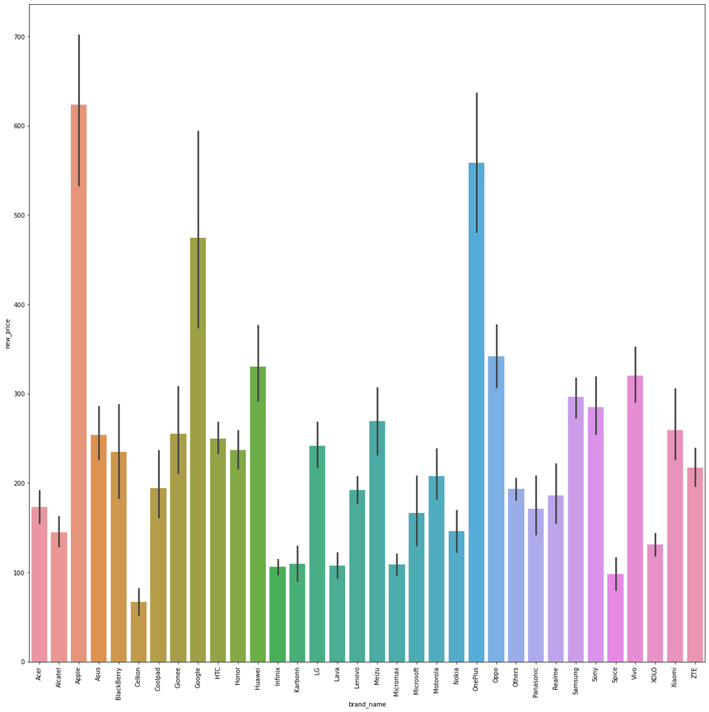

```python
# new_price vs. brand_name barplot
plt.figure(figsize = (20,20))
sns.barplot(data = df1, x = 'brand_name', y = 'new_price')
plt.xticks(rotation = 90)
plt.show()
```

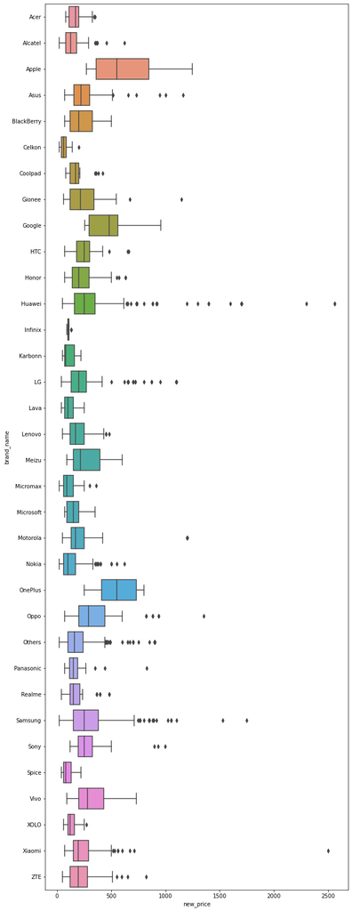

```python
# new_price vs. brand boxplot
plt.figure(figsize = (10,30))
sns.boxplot(data = df1, y = 'brand_name', x = 'new_price')
plt.show()
```

### Observations

```python
# ram vs brand_name
# average ram per brand_name
df1.groupby('brand_name')['ram'].mean().sort_values(ascending = False)
```

```
brand_name
OnePlus       6.363636
Oppo          4.961240
Vivo          4.756410
Huawei        4.655378
Honor         4.603448
Xiaomi        4.583333
Google        4.533333
Meizu         4.451613
Samsung       4.199413
Realme        4.195122
Sony          4.069767
Asus          4.049180
ZTE           4.023214
HTC           4.000000
Apple         4.000000
XOLO          4.000000
Microsoft     4.000000
Panasonic     4.000000
Coolpad       3.954545
Motorola      3.943396
LG            3.936567
Gionee        3.933036
Acer          3.901961
Lenovo        3.885965
BlackBerry    3.829545
Others        3.777888
Spice         3.750000
Micromax      3.679487
Alcatel       3.407025
Karbonn       3.353448
Lava          3.277778
Infinix       2.600000
Nokia         2.420294
Celkon        1.613636
Name: ram, dtype: float64
```

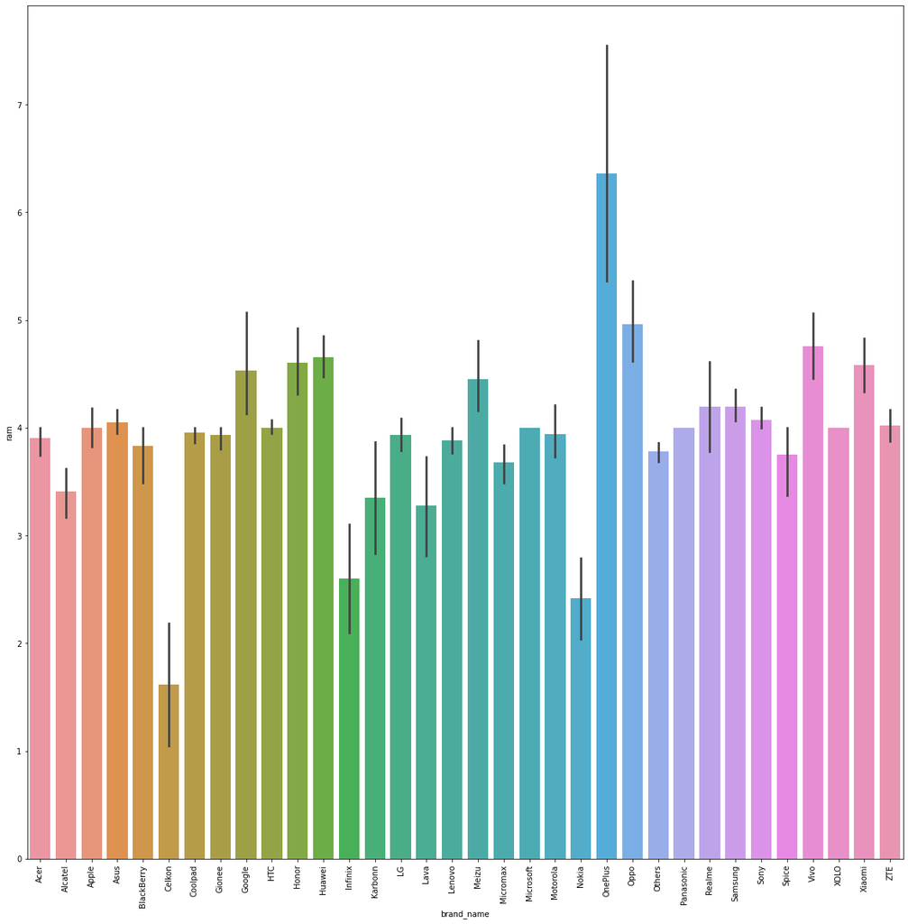

```python
# ram vs. brand_name barplot
plt.figure(figsize = (20,20))
sns.barplot(data = df1, x = 'brand_name', y = 'ram')
plt.xticks(rotation = 90)
plt.show()
```

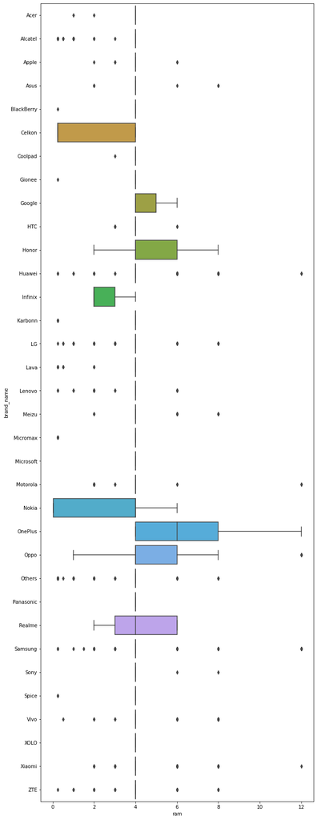

```python
# ram vs. brand boxplot
plt.figure(figsize = (10,30))
sns.boxplot(data = df1, y = 'brand_name', x = 'ram')
plt.show()
```

### Observations

```python
# battery vs brand_name
# average battery per brand_name
df1.groupby('brand_name')['battery'].mean().sort_values(ascending = False)
```

```
brand_name
Infinix       4800.000000
Apple         4628.910256
Realme        4337.317073
Xiaomi        3979.848485
Huawei        3745.159363
Vivo          3718.846154
OnePlus       3716.590909
Honor         3690.517241
Google        3628.333333
Lenovo        3618.479532
Asus          3499.836066
Oppo          3380.581395
Meizu         3368.220339
Samsung       3362.683284
Motorola      3312.594340
Gionee        3117.946429
LG            3033.980100
Sony          3003.372093
Acer          2999.607843
Coolpad       2945.000000
ZTE           2894.821429
BlackBerry    2822.500000
Others        2821.952191
Panasonic     2682.978723
HTC           2614.454545
Alcatel       2452.975207
Microsoft     2382.380952
Nokia         2259.615385
Lava          2248.611111
Micromax      2224.786325
XOLO          2220.000000
Spice         2191.000000
Karbonn       1724.137931
Celkon        1475.757576
Name: battery, dtype: float64
```

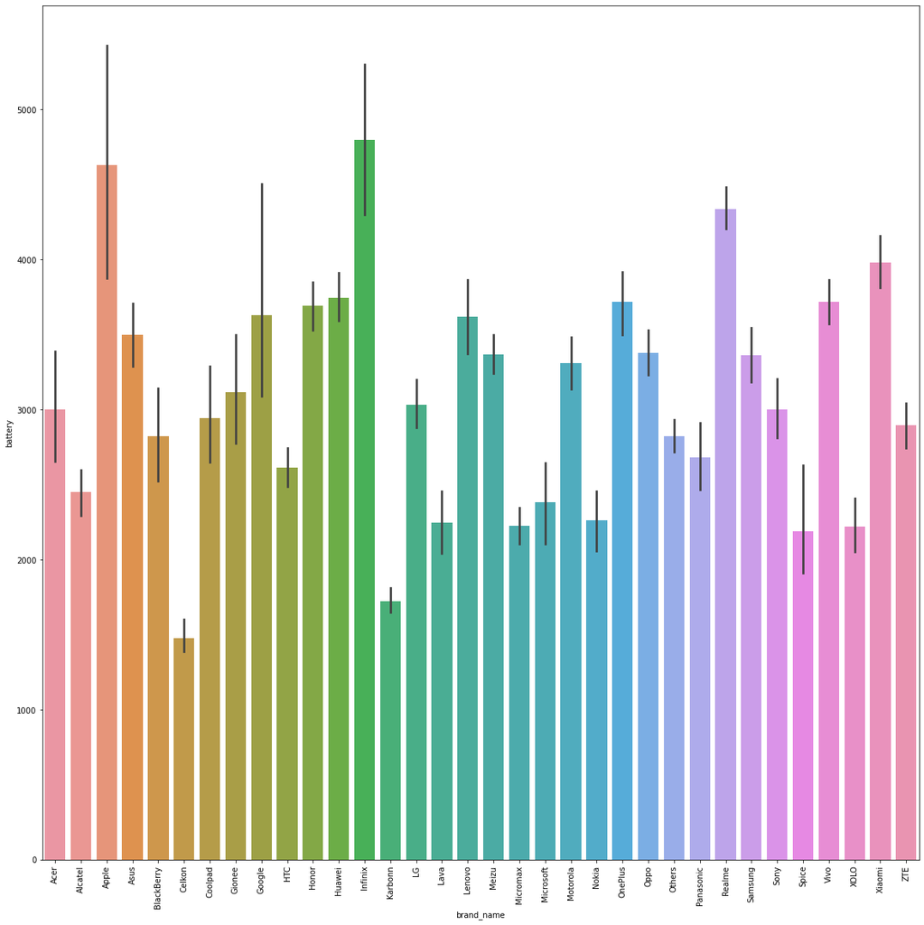

```python
# battery vs. brand_name barplot
plt.figure(figsize = (20,20))
sns.barplot(data = df1, x = 'brand_name', y = 'battery')
plt.xticks(rotation = 90)
plt.show()
```

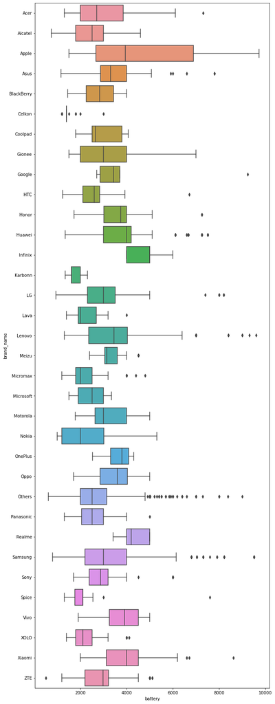

```python
# battery vs. brand_name boxplot
plt.figure(figsize = (10,30))
sns.boxplot(data = df1, y = 'brand_name', x = 'battery')
plt.show()
```

### Observations

- The average device battery capacity ranges from 1476 mAh (Celkon) to 4800 mAh (Infinix).
- Infinx has the highest average battery capacity at 4800 mAh. It has ~171 mAh more capacity than the next highest brand (Apple, approx 4629 mAh).
- Following Apple is Realme averaging 4337 mAh and Xiaomi averaging approx 3980 mAh.
- Google averages 3628 mAh and Samsung averages approx 3363 mAh.

```python
# battery vs weight
# average weight per brand_name
df1.groupby('brand_name')['weight'].mean().sort_values(ascending = False)
```

```
brand_name
Apple         320.423077
Acer          225.872549
Lenovo        223.618129
Asus          218.597541
Huawei        206.978884
Samsung       202.072727
Others        191.411952
Realme        188.804878
Google        187.733333
Xiaomi        184.587879
Infinix       184.400000
OnePlus       181.318182
Sony          180.079070
Honor         179.841379
Vivo          172.914103
Microsoft     172.795455
LG            169.550498
Alcatel       169.010331
Motorola      167.071698
Oppo          166.920543
Gionee        161.476786
Spice         161.130000
Meizu         160.790323
BlackBerry    160.568182
ZTE           156.919643
HTC           155.247273
Coolpad       154.381818
XOLO          151.019048
Panasonic     149.103191
Micromax      146.275214
Nokia         144.883019
Lava          140.408333
Karbonn       138.827586
Celkon        134.621212
Name: weight, dtype: float64
```

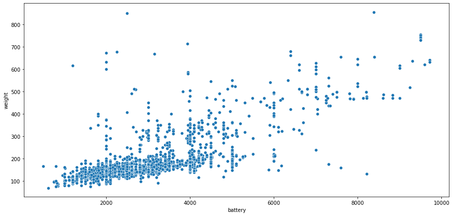

```python
# battery vs weight
plt.figure(figsize=(15,7))
sns.scatterplot(x = 'battery', y = 'weight', data = df1)
plt.show()
```

```python
# battery vs brand_name
# average battery capacity per brand_name
df1.groupby('brand_name')['battery'].mean().sort_values(ascending = False)
```

```
brand_name
Infinix       4800.000000
Apple         4628.910256
Realme        4337.317073
Xiaomi        3979.848485
Huawei        3745.159363
Vivo          3718.846154
OnePlus       3716.590909
Honor         3690.517241
Google        3628.333333
Lenovo        3618.479532
Asus          3499.836066
Oppo          3380.581395
Meizu         3368.220339
Samsung       3362.683284
Motorola      3312.594340
Gionee        3117.946429
LG            3033.980100
Sony          3003.372093
Acer          2999.607843
Coolpad       2945.000000
ZTE           2894.821429
BlackBerry    2822.500000
Others        2821.952191
Panasonic     2682.978723
HTC           2614.454545
Alcatel       2452.975207
Microsoft     2382.380952
Nokia         2259.615385
Lava          2248.611111
Micromax      2224.786325
XOLO          2220.000000
Spice         2191.000000
Karbonn       1724.137931
Celkon        1475.757576
Name: battery, dtype: float64
```

**Questions**:

1. What does the distribution of used device prices look like?
2. What percentage of the used device market is dominated by Android devices?
3. The amount of RAM is important for the smooth functioning of a device. How does the amount of RAM vary with the brand?
4. A large battery often increases a device's weight, making it feel uncomfortable in the hands. How does the weight vary for phones and tablets offering large batteries (more than 4500 mAh)?
5. Bigger screens are desirable for entertainment purposes as they offer a better viewing experience. How many phones and tablets are available across different brands with a screen size larger than 6 inches?
6. Budget devices nowadays offer great selfie cameras, allowing us to capture our favorite moments with loved ones. What is the distribution of budget devices offering greater than 8MP selfie cameras across brands?
7. Which attributes are highly correlated with the price of a used device?

### Question 1 - What does the distribution of used device prices look like?

```python
histogram_boxplot(df1, 'used_price')

print('The distribution of the used device prices is highly skewed to the right with a long tail to the right')
```

[output not shown]

```
The distribution of the used device prices is highly skewed to the right with a long tail to the right
```

### Question 2 - What percentage of the used device market is dominated by Android devices?

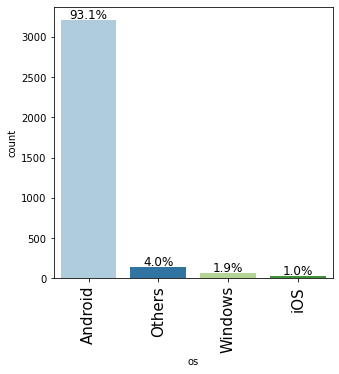

```
93.1% is the percentage of the used device market dominated by Android devices
```

```python
labeled_barplot(df1, 'os', perc = True)

print('93.1% is the percentage of the used device market dominated by Android devices')
```

### Question 3 - The amount of RAM is important for the smooth functioning of a device. How does the amount of RAM vary with the brand?

```python
# average ram per brand_name
df1.groupby('brand_name')['ram'].mean().sort_values(ascending = False)
```

```
brand_name
OnePlus       6.363636
Oppo          4.961240
Vivo          4.756410
Huawei        4.655378
Honor         4.603448
Xiaomi        4.583333
Google        4.533333
Meizu         4.451613
Samsung       4.199413
Realme        4.195122
Sony          4.069767
Asus          4.049180
ZTE           4.023214
HTC           4.000000
Apple         4.000000
XOLO          4.000000
Microsoft     4.000000
Panasonic     4.000000
Coolpad       3.954545
Motorola      3.943396
LG            3.936567
Gionee        3.933036
Acer          3.901961
Lenovo        3.885965
BlackBerry    3.829545
Others        3.777888
Spice         3.750000
Micromax      3.679487
Alcatel       3.407025
Karbonn       3.353448
Lava          3.277778
Infinix       2.600000
Nokia         2.420294
Celkon        1.613636
Name: ram, dtype: float64
```

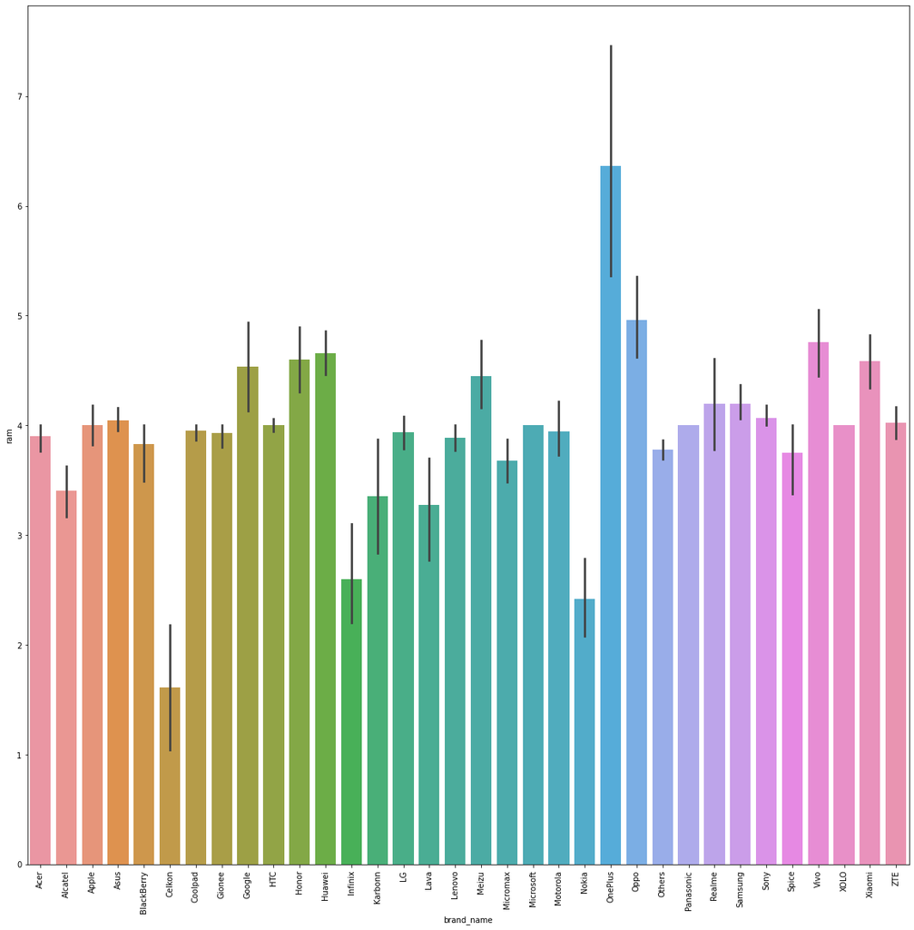

```python
# ram vs. brand_name barplot
plt.figure(figsize = (20,20))
sns.barplot(data = df1, x = 'brand_name', y = 'ram')
plt.xticks(rotation = 90)
plt.show()
```

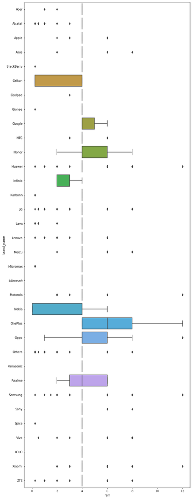

```python
# ram vs. brand boxplot
plt.figure(figsize = (10,30))
sns.boxplot(data = df1, y = 'brand_name', x = 'ram')
plt.show()
```

### Question 4 - A large battery often increases a device's weight, making it feel uncomfortable in the hands. How does the weight vary for phones and tablets offering large batteries (more than 4500 mAh)?

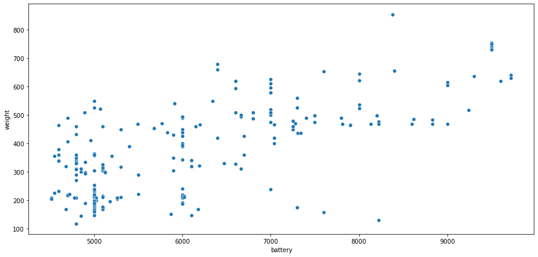

```
The scatterplot shows a positive correlation. As battery capacity increases, for most devices, the weight is also increasing
```

```python
# Creating a copy of the dataframe
df_battery = df1.copy()

# Creating a new dataframe that only contains values for a larger battery (battery > 4500 mAh)
larger_battery = df_battery[df_battery['battery'] > 4500]

# plotting the distribution of battery where battery > 4500 against weight
# battery vs weight
plt.figure(figsize=(15,7))
sns.scatterplot(x = 'battery', y = 'weight', data = larger_battery)
plt.show()

print('The scatterplot shows a positive correlation. As battery capacity increases, for most devices, the weight is also increasing')
```

### Question 5 - Bigger screens are desirable for entertainment purposes as they offer a better viewing experience. How many phones and tablets are available across different brands with a screen size larger than 6 inches?

```python
# Creating a copy of the dataframe
df_screen = df1.copy()

# Converting 6 inches to cm since all devices in the dataset are in cms
# 1 inch = 2.54 cm/inch
# 6 inches * 2.54 cm/inch = 15.24 cm

# Creating a new dataframe that shows only the brands that have a screen size larger than 6 inches (15.24 cm)
brand_big_screen = df_screen[df_screen['screen_size'] > 15.24]['brand_name'].value_counts()
brand_big_screen

# Displaying the total number of devices that have a screen larger than 6 inches (15.24 cm)
print('The total number of devices that have a screen larger than 6 inches (15.24 cm) is', df_screen[df_screen['screen_size'] > 15.24]['brand_name'].value_counts().sum())
```

```
The total number of devices that have a screen larger than 6 inches (15.24 cm) is 1099
```